# Regression Problem

Jaclyn A Coate

2019-11-25

```r
library(readxl)
library(tidyverse)
library(skimr)
library(corrplot)
library(cowplot)
library(ggthemes)
```

```r
frito <- read.csv("https://raw.githubusercontent.com/JaclynCoate/MDS-6306-Doing-Data-Science-Fall-2019/Master/Unit%2014%20and%2015%20Case%20Study%202/CaseStudy2-data.csv", header = TRUE, strip.white=TRUE)
```

# Salary Model

## Exploratory Data Analysis

- Linear Regression
- Multiple Linear Regression
- Correlation
- Causation?

## Steps For EDA w/ Large Number of Categories / Continuous Variables

1. Check for NAs
2. Get rid of zero value variables (ones that only have one value).
3. Use common sense! (variables that don’t makes sense remove from your list of variables)
   - e.g. ID, Employee Number
4. Check and make sure categorical variables are stored as factors.
   - e.g. Make sure all variables are categorized correctly - categorical (stock options) or numeric
5. Storing all level numeric variables as factors
   - e.g. Job Level, College, etc.
6. Checking for highly correlated numeric variables
   - Highly correlated values can weaken the model.
   - e.g. Monthly Salary, Weekly Salary, they say the same thing and would be highly correlated
7. Numeric | Numeric
8. Numeric | Categorical
9. MSPE Model

```r
#Categorical:
# "Attrition", "Department", "BusinessTravel", "EducationField", "Gender", "JobRole", "MaritalStatus", "Over18", "OverTime"

# Level
# "JobInvolvement", "EnvironmentSatisfaction", "Education", "JobLevel", "JobSatisfaction", "PerformanceRating", "RelationshipSatisfaction", "StockOptionLevel", "WorkLifeBalance"

#Continuous:
# "Age", "DailyRate", "DistanceFromHome", "EmployeeCount", "HourlyRate", "MonthlyIncome", "MonthlyRate", "NumCompaniesWorked", "StandardHours" "PercentSalaryHike", "TotalWorkingYears", "TrainingTimesLastYear", "YearsAtCompany", "YearsInCurrentRole", "YearsSinceLastPromotion", "YearsWithCurrManager"

# All Variables
# "Attrition", DailyRate", "Department", "DistanceFromHome", "Education", "EducationField", "EmployeeCount", "EnvironmentSatisfaction", "Gender", "HourlyRate", "JobInvolvement", "JobLevel", "JobRole", "JobSatisfaction", "MaritalStatus", "MonthlyIncome",  "MonthlyRate", "NumCompaniesWorked", "Over18", "OverTime", "PercentSalaryHike", "PerformanceRating", "RelationshipSatisfaction", "StandardHours", "StockOptionLevel", "TotalWorkingYears", "TrainingTimesLastYear", "WorkLifeBalance", "YearsAtCompany", "YearsInCurrentRole", "YearsSinceLastPromotion", "YearsWithCurrManager"
```

```r
#frito
#ncol(frito)
#skim(frito)
```

### 1. Drop NAs

- Completed on previous EDA. Data is clean.

### 2. Dropping all zero variance variables

- Drop Variables: EmployeeCount, Over18, StandardHours due to zero variance in sd column of skim() feature output

```r
frito2 <- select(frito, -c("EmployeeCount", "Over18", "StandardHours"))
#skim(frito2)
#ncol(frito2)
```

### 3. Remove logically irrelevant variables

- “EmployeeNumber”: not related to salary
- “ID”: not related to salary
- “PerformanceRating” : removed because this is a self given performacne rating and emoloyees would still work towards the best raises even when possibly planning on leaving the company

```r
#skim(frito2)
#view(frito2)

frito3 <- select(frito2, -c("EmployeeNumber", "ID", "PerformanceRating"))
#skim(frito3)
#ncol(frito3)
```

### 4. Storing all categorical variables as factors

- Confirmed the below variables are stored as factors with skim() function output
  - “Attrition”, “BusinessTravel”, “Department”, “EducationField”, “Gender”, “JobRole”, “MaritalStatus”, “OverTime”

```r
# Categorical Variables
#skim(frito3)
```

### 5. Storing all level numeric variables as factors

- Using the as.factor function to change all level numerical varibales to be stored as factors
  - “JobInvolvement”, “EnvironmentSatisfaction”, “Education”, “JobLevel”, “JobSatisfaction”, “RelationshipSatisfaction”, “StockOptionLevel”, “WorkLifeBalance”

```r
frito3$Education <- as.factor(frito3$Education)
frito3$EnvironmentSatisfaction <- as.factor(frito3$EnvironmentSatisfaction)
frito3$JobLevel <- as.factor(frito3$JobLevel)
frito3$JobInvolvement <- as.factor(frito3$JobInvolvement)
frito3$JobSatisfaction <- as.factor(frito3$JobSatisfaction)
frito3$RelationshipSatisfaction <- as.factor(frito3$RelationshipSatisfaction)
frito3$StockOptionLevel <- as.factor(frito3$StockOptionLevel)
frito3$WorkLifeBalance <- as.factor(frito3$WorkLifeBalance)

#skim(frito3)
#ncol(frito3)
```

### 6. Checking for highly correlated numeric variables

- Monthly Income correlated variables
  - Monthly Income v Total Working Years: .78
  - Monthly Income v Age: .48
  - Monthly Income v Years in Current Role: .36
  - Monthly Income v Years At Company: .49
  - Monthly Income v Years With Current Manager: .33
  - Monthly Income v Years Since Last Promotion:.32

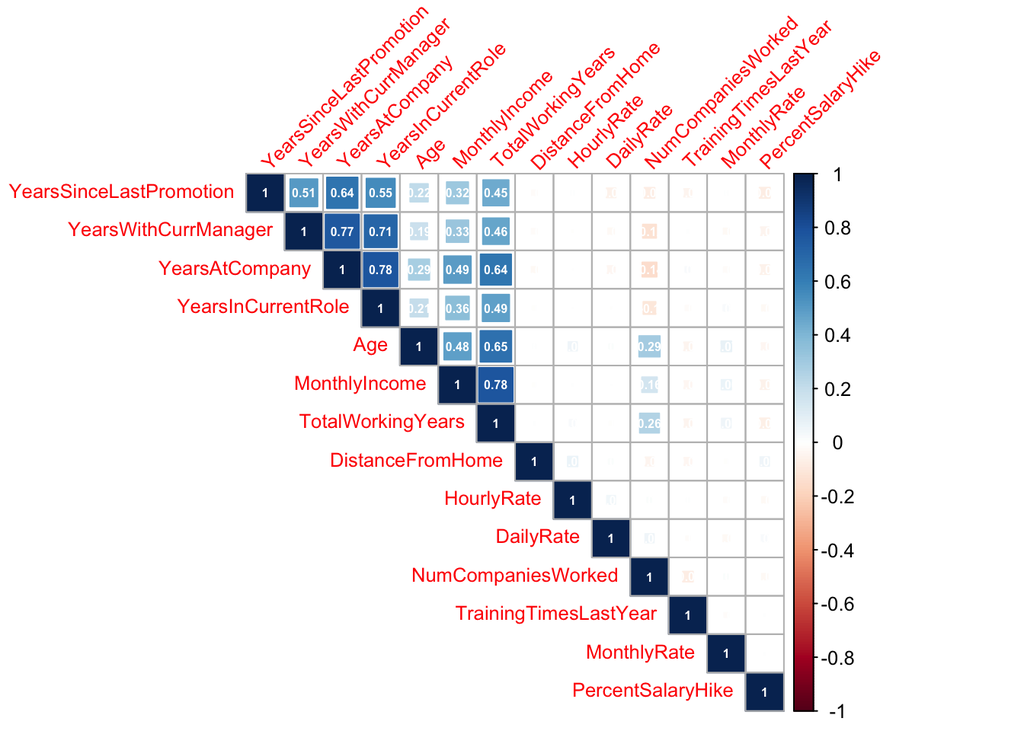

```r
corrFrito <- frito3

corrFritotable <- corrFrito %>% keep(is.numeric) %>% na.omit %>% cor %>% view

corrFrito %>% keep(is.numeric) %>% na.omit %>% cor %>% corrplot("upper", addCoef.col = "white", number.digits = 2, number.cex = 0.5, method="square", order="hclust", tl.srt=45, tl.cex = 0.8)
```

```r
invisible(view(corrFritotable))
```

#### Correlation Review

- Many of these varaibles above that are correlated with Monthly Salar are also correlated with eachother
  - Including all of them would weaken the model
  - Decided to keep the highest correlated: Total Working Years
  - Dopping all variables that correlated with Total Working Years
    - “Age”, “YearsInCurrentRole”, “YearsAtCompany”, “YearsWithCurrManager”, “YearsSinceLastPromotion”

```r
frito4 <- select(frito3, -c("Age", "YearsInCurrentRole", "YearsAtCompany", "YearsWithCurrManager", "YearsSinceLastPromotion"))
#skim(frito4)
#ncol(frito4)
```

### 7. Automatic EDA: Numeric v Numeric

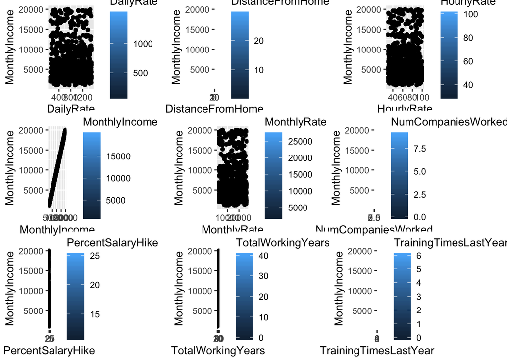

```r
# 1. Name target variable
targetNumCat1 <- frito4 %>% keep(is.numeric) %>% colnames

# 2. Name explanatory variable
numvariables1 <- "MonthlyIncome"

# 3. Create function
numCatplot1 <- function(df, explan, resp) {
  ggplot(data = df) + geom_point(aes_string(x = explan, y = resp, fill = explan)) + xlab(explan) + ylab(resp)
}

# 4. Create plot list for plot_grid function to reference
plotlistNumCat1 <- lapply(targetNumCat1, function(x) numCatplot1(frito3, x, numvariables1))

# 5. Grid of all categorical variables plotted against Attrition
plot_grid(plotlist = plotlistNumCat1)
```

#### Numeric v Numeric Review

- Upon reviewing the large grid of remaining numerical variables we can clearly see random clouds with no real correlation between Monthly Income and the remaining vaiables.
  - Keep: “MonthlyIncome”, “TotalWorkingYears”
  - Drop: “PercentSalary”

```r
#skim(frito4)
frito5 <- select(frito4, -c("DailyRate", "DistanceFromHome", "HourlyRate", "MonthlyRate", "NumCompaniesWorked", "PercentSalaryHike", "TrainingTimesLastYear"))
#skim(frito5)
#ncol(frito5)
```

### 8. Automatic EDA: Numeric v Categorical

- X | Y
- Comparison of Monthly Income (dependent variable of interest) to categorical variables left in model
- Density plot
  - Colored by Monthly Income
  - If density plot shows peaks in separate areas then important variable
  - If density plot shows peaks in the same spot (clean overlay) then not an important variable

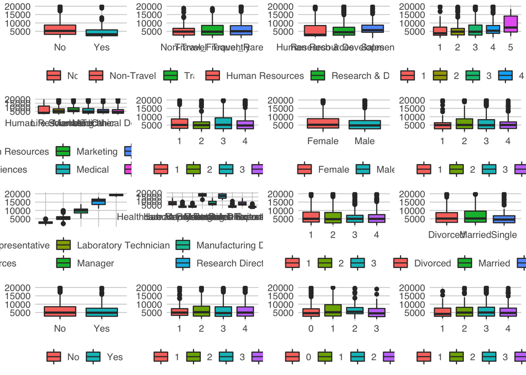

```r
# 1. Name target variable
targetNumCat2 <- frito5 %>% keep(is.factor) %>% colnames

# 2. Name explanatory variable
numvariables2 <- "MonthlyIncome"

# 3. Create function
numCatplot2 <- function(df, explan, resp) {
  ggplot(data = df) + geom_boxplot(aes_string(x = explan, y = resp, fill = explan)) + xlab(explan) + ylab("") + theme_excel_new()
}

# 4. Create plot list for plot_grid function to reference
plotlistNumCat2 <- lapply(targetNumCat2, function(x) numCatplot2(frito3, x, numvariables2))

# 5. Grid of all categorical variables plotted against Attrition
plot_grid(plotlist = plotlistNumCat2)
```

#### Numeric v Categorical Review

- Upon reviewing the large grid we were able to drop those categorical variables that do not have a lot of visible difference between the different categories within a variable.
  - “Attrition”, “BusinessTravel”, “Department”, “EducationField”, “EnvironmentSatisfaction”, “Gender”, “JobInvolvement”, “JobSatisfaction”, “MaritalStatus”, “OverTime”, “RelationshipSatisfaction”, “WorkLifeBalance”, “StockOptionLevel”,
- Upon reviewing the large grid we were able to easily see a few categorical variables that had large differences between the levels
  - “Eduction”, “JobLevel”, “JobRole”

```r
frito6 <- select(frito5, c("MonthlyIncome", "JobLevel", "JobRole", "TotalWorkingYears", "Education"))
#skim(frito6)
#ncol(frito6)
```

#### Monthly Income v Education

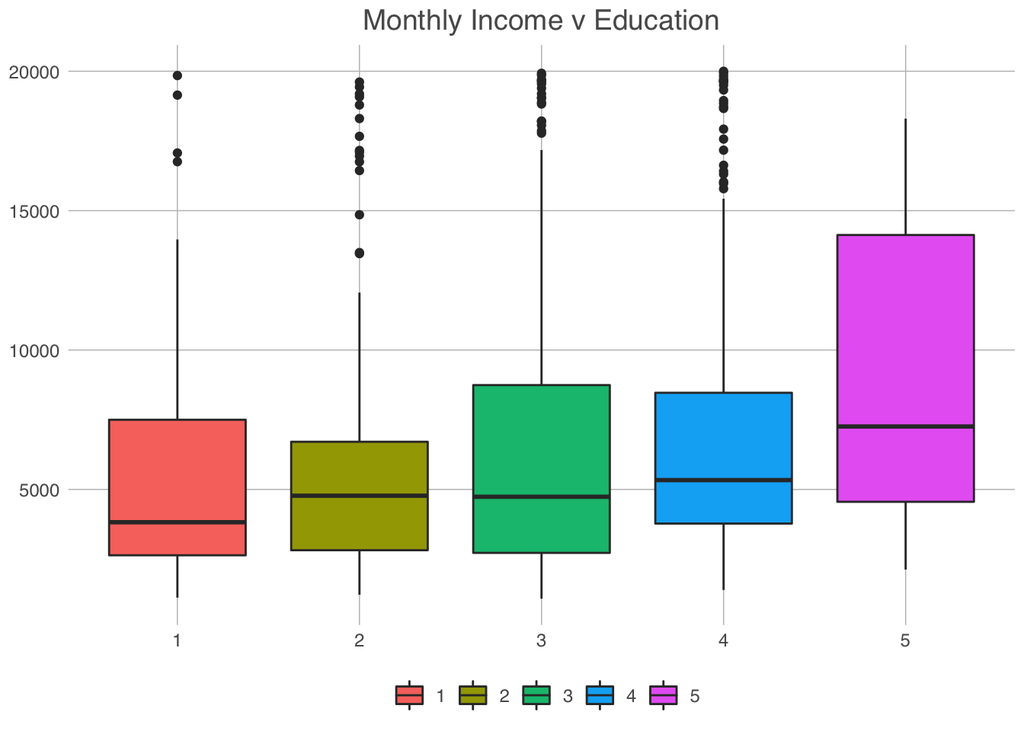

```r
frito6 %>% ggplot() + geom_boxplot(aes(x = Education, y = MonthlyIncome, fill = Education)) +
  theme_excel_new() + ggtitle("Monthly Income v Education") + ylab("Education")
```

#### Monthly Income v Job Level

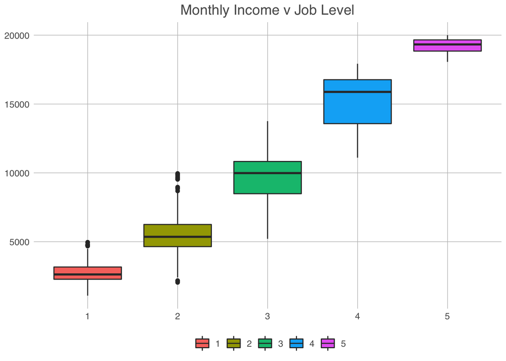

```r
frito6 %>% ggplot() + geom_boxplot(aes(x = JobLevel, y = MonthlyIncome, fill = JobLevel)) +
  theme_excel_new() + ggtitle("Monthly Income v Job Level") + ylab("")
```

#### Monthly Income v Job Role

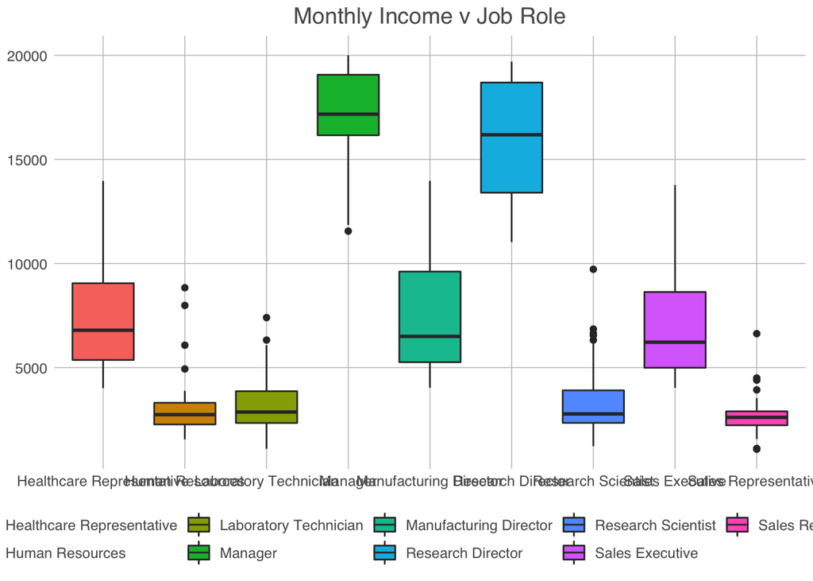

```r
frito6 %>% ggplot() + geom_boxplot(aes(x = JobRole, y = MonthlyIncome, fill = JobRole)) +
  theme_excel_new() + ggtitle("Monthly Income v Job Role") + ylab("")
```

#### Numeric v Categorical Review

- Upon closer look at the three remaining categorical variabels to utilize we have deicded to only keep 2 of the 3 original variables retained.
  - “JobLevel”, “JobRole”

```r
frito7 <- select(frito6, c("MonthlyIncome", "JobLevel", "JobRole", "TotalWorkingYears"))
#skim(frito7)
```

## MSPE Model:

- Variables: “JobLevel”, “JobRole”, “TotalWorkingYears”

## MSPE Model:

- MonthlyIncome = B_0 + B_1 * TotalWorkingYears + B_2 * JobRole + B_3 * JobLevel

```r
set.seed(3)
splitPerc = .8

trnIndFrito = sample(1:dim(frito7)[1], round(splitPerc * dim(frito7)[1]))
trainFrito = frito7[trnIndFrito,]
testFrito = frito7[-trnIndFrito,]
```

## MSPE Model:

- MonthlyIncome = B_0 + B_1 * TotalWorkingYears + B_2 * JobRole + B_3 * JobLevel

```r
FritoModel1 = lm(MonthlyIncome ~ TotalWorkingYears + JobRole + JobLevel, data = trainFrito)
invisible(summary(FritoModel1))

FritoModelPres1 = predict(FritoModel1, newdata = testFrito)

MSPE1 = sqrt(mean((testFrito$MonthlyIncome - FritoModelPres1)^2))
MSPE1
```

```
## [1] 930.998
```

# Predicting Salary

```r
NoSalary <- read_excel("/Users/Jaco/Desktop/SMU/Fall2019/DS_6306_Doing_Data_Science/Unit_14CaseStudy2/CaseStudy2CompSetNoSalary.xlsx")
#NoSalary
```

```r
NoSalary <- select(NoSalary, c("JobLevel", "TotalWorkingYears", "JobRole"))
#skim(NoSalary)

NoSalary$JobLevel <- as.factor(NoSalary$JobLevel)
NoSalary$JobRole <- as.factor(NoSalary$JobRole)

skim(NoSalary)
```

```
## Skim summary statistics
##  n obs: 300
##  n variables: 3
##
## ── Variable type:factor ────────────────────────────────────────────────────────────────────────────────────────────────────────────────────
##  variable missing complete   n n_unique                         top_counts
##  JobLevel       0      300 300        5       2: 118, 1: 108, 3: 49, 4: 16
##   JobRole       0      300 300        9 Sal: 69, Res: 59, Lab: 51, Man: 27
##  ordered
##    FALSE
##    FALSE
##
## ── Variable type:numeric ───────────────────────────────────────────────────────────────────────────────────────────────────────────────────
##           variable missing complete   n  mean   sd p0 p25 p50 p75 p100
##  TotalWorkingYears       0      300 300 10.78 7.62  0   6   9  14   40
##      hist
##  ▅▇▂▂▁▁▁▁
```

```r
estimates <- predict(FritoModel1, newdata = NoSalary)
as.data.frame(estimates)
```

```
##     estimates
## 1    5650.932
## 2    2796.883
## 3   12896.333
## 4    2592.903
## 5    2688.132
## 6    4953.470
## 7    5698.547
## 8    2450.058
## 9    3034.957
## 10  13254.537
## 11   9744.329
## 12   2688.132
## 13   5603.317
## 14   5555.702
```

[output cut: 286 more lines]

```r
SalaryEstim <- cbind(NoSalary, estimates)
SalaryEstim
```

```
##     JobLevel TotalWorkingYears                   JobRole estimates
## 1          2                 7           Sales Executive  5650.932
## 2          1                 5        Research Scientist  2796.883
## 3          4                24           Sales Executive 12896.333
## 4          1                 5     Laboratory Technician  2592.903
## 5          1                 7     Laboratory Technician  2688.132
## 6          2                19      Sales Representative  4953.470
## 7          2                 8           Sales Executive  5698.547
## 8          1                 2     Laboratory Technician  2450.058
## 9          1                10        Research Scientist  3034.957
## 10         4                29    Manufacturing Director 13254.537
## 11         3                28           Sales Executive  9744.329
## 12         1                 7     Laboratory Technician  2688.132
## 13         2                 6           Sales Executive  5603.317
## 14         2                 5           Sales Executive  5555.702
```

[output cut: 286 more lines]

# Write CSV of fitted No Salary Data Set

```r
#write_csv(SalaryEstim, "/Users/Jaco/Desktop/SMU/Fall2019/DS_6306_Doing_Data_Science/Unit_14CaseStudy2\\NoSalaryFinal.csv")
```